MRC Centre for Global Infectious Disease Analysis, Imperial College London

# Uzbekistan COVID-19 report

## Situation Report for COVID-19: Uzbekistan, 2021-07-02

#### **[Download the report for Uzbekistan, 2021-07-02 here](https://github.com/mrc-ide/global-lmic-reports/raw/master/UZB/index.pdf).**

This report uses data from COVID-19 Data Repository by the Center for Systems Science and Engineering (CSSE) at Johns Hopkins University. These data are updated daily and whilst there may be a short delay, they are generally consistent with Ministry reports. These data are then used to back-calculate an ‘inferred number of COVID-19 infections’ using mathematical modelling techniques (see [Report 12](https://www.imperial.ac.uk/mrc-global-infectious-disease-analysis/covid-19/report-12-global-impact-covid-19/) for further details) to estimate the number of people that have been infected and to make short-term projections for future healthcare needs.

### Epidemiological Situation

| **Total Reported Cases** | **New Reported Cases** | **Total Reported Deaths** | **New Reported Deaths** | **Estimated $R_{eff}$** |
| --- | --- | --- | --- | --- |
| 111,648 | 495 | 742 | 2 | 1.28 (95% CI: 1.18-1.36) |

The figure below shows the cumulative reported deaths as a function of the time since the 10th death was reported. Dashed lines show the expected trajectory for different doubling times of the epidemic. For example, with a doubling time of 3 days, if there are currently a total of 20 deaths reported, we would expect there to be 40 deaths in total reported in 3 days-time, 80 deaths in 6 days-time, 160 deaths in 9 days-time etc. For most epidemics, in the absence of interventions, we expect a doubling time of 3-4 days for this disease.

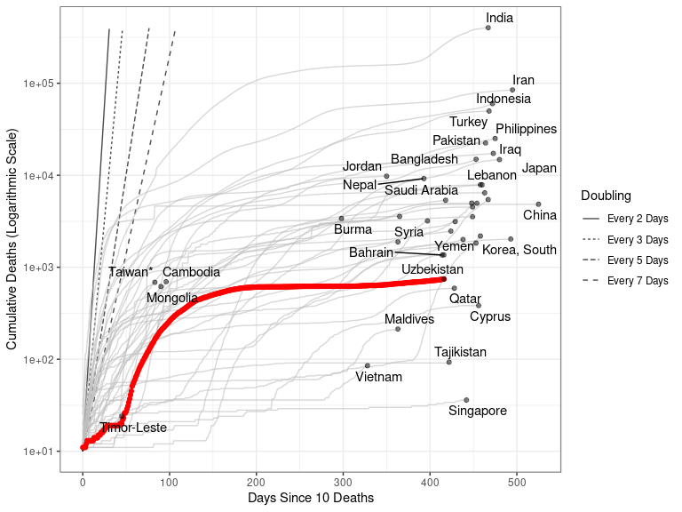

**Figure 1: Cumulative Deaths since 10 deaths.** Country not shown if fewer than 10 deaths.

### COVID-19 Transmission Modelling

The figure below shows the estimated number of people infected over the past 4 weeks. The bar charts show, for comparison, the number of reported cases. We estimate that there has been a total of 40,447 (95% CI: 37,575-43,319) infections over the past 4 weeks. The right-hand plot shows these data on a different scale as the estimated infections are likely to be much larger than the reported cases. **Importantly**, the estimated infections includes both asymptomatic and mild cases that would not necessarily be identified through surveillance. Consequently, the estimated infections are likely to be significantly higher than the reported cases in all countries (see our [FAQ](https://mrc-ide.github.io/global-lmic-reports/FAQ.html#why-are-the-estimated-infections-so-much-higher-than-the-reported-cases) for further explanation of these differences and why the reported cases and estimated infections are unlikely to match).

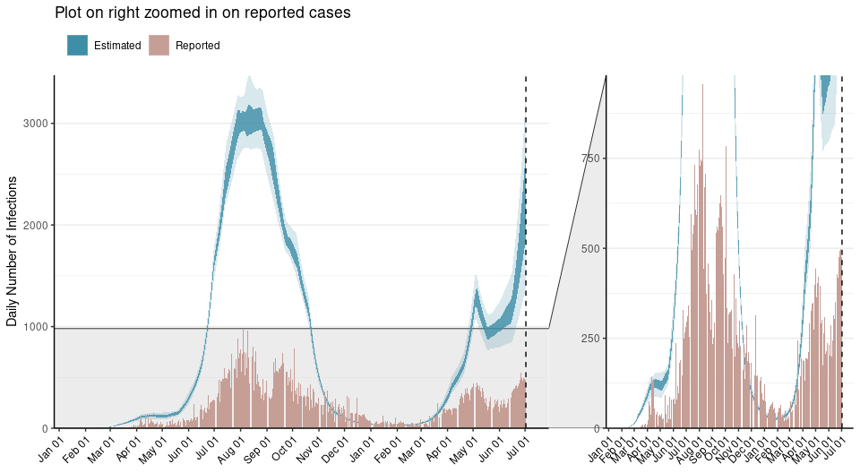

**Figure 2: Daily number of infections estimated by fitting to the current total of deaths.** Reported cases are shown in red. Model estimated infections are shown in blue (dark blue 50% interquartile range, light blue 95% quantile). The dashed line shows the current day.

By fitting to the time series of deaths, we are able to estimate a time-varying reproduction number, $R_{eff}$. $R_{eff}$ is the the average number of secondary infections caused by a single infected person at a given time. If $R_{eff}$ is above 1, the rate of transmission is increasing and the number of new infections is increasing. $R_{eff}$ is assumed to change in relation to mobility fall in proportion. When fitting our model we assume that 100% of COVID-19 related deaths have been reported (please see our [FAQ](https://mrc-ide.github.io/global-lmic-reports/FAQ.html#how-have-you-accounted-for-unreported-deaths) section for more information about this assumption). Additionally, we assume that infection with COVID-19 leads to protective immunity that does not wane within the time scales considered in these analyses.

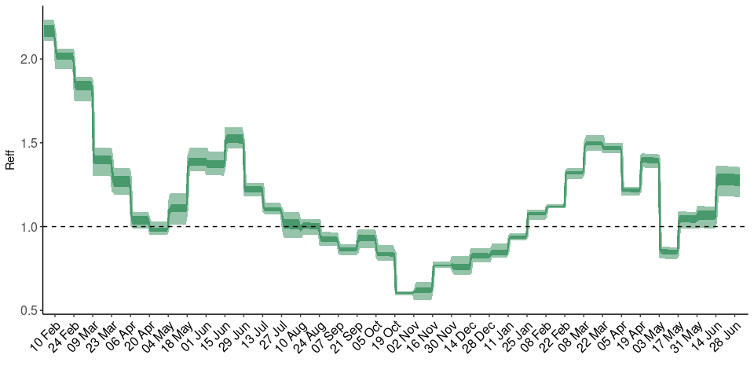

**Figure 3: Time-varying effective reproduction number, $R_{eff}$.** $R_{eff}$ (**green**) is the average number of secondary infections caused by a single infected person at time equal to $t$. A horizonatal dashed line is shown at $R_{eff}$ = 1. $R_{eff}$ < 1 indicates a slowing epidemic in which new infections are not increasing. $R_{eff}$ > 1 indicates a growing epidemic in which new infections are increasing over time. Dark green shows the 50% CI and light green shows the 95% CI

Using the model fit, we can forecast the expected trajectory for cumulative deaths assuming the transmission level, represented by the final Rt value stays the same over the next 28 days.

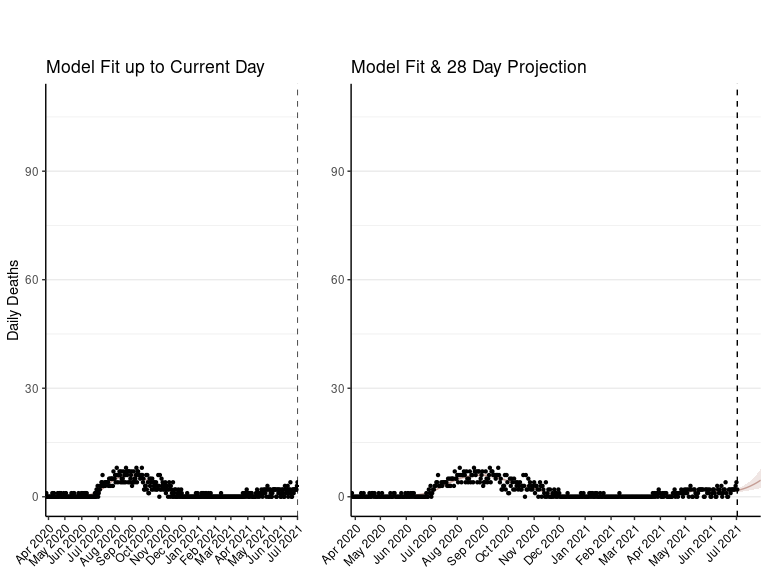

**Figure 4: Estimated daily deaths.** Projected deaths assuming the current level of interventions are maintained are shown in red (median and 95% quantile). Reported deaths are plotted in black. The plot on the left is focussed on the model fit prior to today, while the plot on the right forecasts the next 28 days.

### Short-term Epidemic Scenarios

We make the following short-term projections of healthcare demand and new infections under the following three scenarios:

- **Scenario 1.** The epidemic continues to grow at the current rate.
- **Scenario 2.** Countries will further scale up interventions (either increasing current strategies or implementing new interventions) leading to a further 50% reduction in transmission.
- **Scenario 3.** Countries will relax current interventions by 50%

**N.B. These scenarios currently assume that the impact of mobility on transmission will remain the same in the future as it has in the past. We are working to extend methods to estimate the impact of increases in mobility on transmission as lockdown and interventions are reversed. Consequently, projection are likely to represent an upper estimate of the healthcare demand and case load for each scenario**

We estimate that over the next 4 weeks demand for hospital beds will change from 95 (95% CI: 88-102) patients requiring treatment with high-pressure oxygen at the current date to 262 (95% CI: 233-291) hospital beds being required on 2021-07-30 if no further interventions are introduced (Scenario 1). Similarly, we estimate that over the next 4 weeks demand for critical care (ICU) beds will change from 37 (95% CI: 35-40) patients requiring treatment with mechanical ventilation at the current date to 100 (95% CI: 89-111) by 2021-07-30. These projections assume that approximately 5% of all infections will require treatment with high-pressure oxygen and that approximately 30% of hospitalised cases will require treatment with mechanical ventilation (based on analysis of ongoing epidemics in Europe). **N.B. These scenarios are unlikely to show significant differences for the first week since there is a delay of approximately 10 days between infection and hospital admission. Consequently, the effectiveness of a change in policy is likely to be better captured by hospital admission data approximately 2 weeks after the policy change is implemented.**

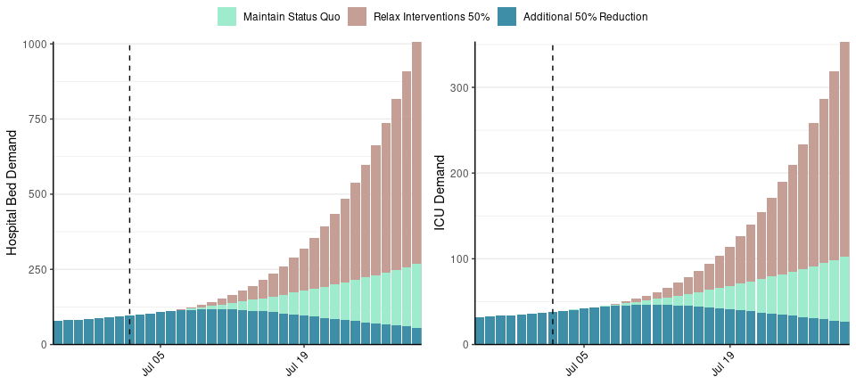

**Figure 5: Healthcare demands in the next 28 days.** Individuals needing an ICU bed are assumed to need mechanical ventilation. Projected demand for Scenario 1 (the epidemic continues to grow at the current rate) are shown in green (Maintain status quo). Projections for Scenario 2 (a further 50% reduction in transmission) are shown in blue. Projections for Scenario 3 (relaxing interventions by 50%) are shown in red. Current date shown with dashed line.

The impact of each scenario has a more immediate effect on the daily number of infections. The figure below shows the impact of each scenario on the estimated daily incidence of new infections. If interventions are scaled up (Scenario 2), the daily number of infections will change from 2,252 (95% CI: 2,058-2,447) at the current date to 409 (95% CI: 361-457) by 2021-07-30. If current interventions were relaxed by 50%, we estimate the daily number of infections will change from 2,252 (95% CI: 2,058-2,447) at the current date to 45,025 (95% CI: 39,247-50,803) by 2021-07-30.

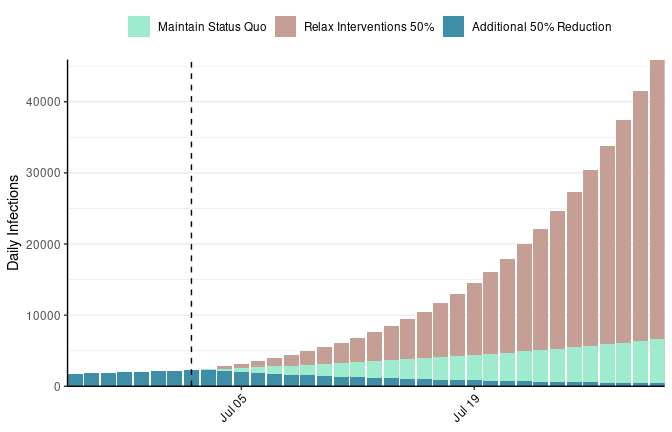

**Figure 6: Daily number of infections estimated by fitting to deaths.** Projected infections for Scenario 1 (the epidemic continues to grow at the current rate) are shown in green (Maintain status quo). Projections for Scenario 2 (a further 50% reduction in transmission) are shown in blue. Projections for Scenario 3 (relaxing interventions by 50%) are shown in red. Current date shown with dashed line.

To explore different scenarios, we recommend using our [COVID-19 Scenario Analysis Tool - https://covidsim.org/](https://covidsim.org/), which can be used to simulate different intervention scenarios and explore the long term impact on healthcare demand.

Copyright © 2020 Imperial College London. MRC Centre for Global Infectious Disease Analysis. All rights reserved.

Funded by the Wellcome Trust and The Department for International Development